# Research Guide

Baseball players, 4,620 rows

Research Guide

## Categorical

last name

`nameLast`

Player's last name

**PROPERTIES**:

| STAT | VAL | PER |
| --- | --- | --- |
| Rows | 4,620 |  |
| Distinct | 3,099 | (67.1%) |

[figure not shown]

**PREVIEW**:

```
Johnson · Perez · Martinez · Jones · Davis · Wilson · Hernandez · Rodriguez · Smith
Williams · Gonzalez · Ramirez · Young · Anderson · Brown · Miller · Garcia · Sanchez
Castillo · Cruz · Jackson · Lopez · Thompson · Walker · Pena · Bell · Cabrera
Clark · Hill · Reed · Diaz · Harris · Moore · Ortiz · Rivera · White · Wright
```

**FACTOR LEVELS**:

| Frequency | (%) | Label |
| --- | --- | --- |
| 28 | (0.6%) | Johnson |
| 28 | (0.6%) | Perez |
| 26 | (0.6%) | Martinez |
| 25 | (0.5%) | Jones |
| 24 | (0.5%) | Davis |
| 24 | (0.5%) | Wilson |
| 21 | (0.5%) | Hernandez |
| 19 | (0.4%) | Rodriguez |
| 19 | (0.4%) | Smith |
| 19 | (0.4%) | Williams |
| 18 | (0.4%) | Gonzalez |
| 18 | (0.4%) | Ramirez |
| 17 | (0.4%) | Young |
| 16 | (0.3%) | Anderson |
| 16 | (0.3%) | Brown |
| 16 | (0.3%) | Miller |
| 15 | (0.3%) | Garcia |
| 14 | (0.3%) | Sanchez |
| 12 | (0.3%) | Castillo |
| 12 | (0.3%) | Cruz |
| 12 | (0.3%) | Jackson |
| 12 | (0.3%) | Lopez |
| 12 | (0.3%) | Thompson |
| 12 | (0.3%) | Walker |
| 11 | (0.2%) | Pena |
| 10 | (0.2%) | Bell |
| 10 | (0.2%) | Cabrera |
| 10 | (0.2%) | Clark |
| 10 | (0.2%) | Hill |
| 10 | (0.2%) | Reed |
| 9 | (0.2%) | Diaz |
| 9 | (0.2%) | Harris |
| 9 | (0.2%) | Moore |
| 9 | (0.2%) | Ortiz |
| 9 | (0.2%) | Rivera |
| 9 | (0.2%) | White |
| 9 | (0.2%) | Wright |
| 8 | (0.2%) | Alvarez |
| 8 | (0.2%) | Green |
| 8 | (0.2%) | Lee |
| 8 | (0.2%) | Murphy |
| 8 | (0.2%) | Wood |
| 7 | (0.2%) | Adams |
| 7 | (0.2%) | Hall |
| 7 | (0.2%) | Lewis |
| 7 | (0.2%) | Morris |
| 7 | (0.2%) | Myers |
| 7 | (0.2%) | Patterson |
| 7 | (0.2%) | Powell |
| 7 | (0.2%) | Reyes |

categorical · geographic

city of birth

`birthCity`

City where the player was born; blank if unknown

**PROPERTIES**:

| STAT | VAL | PER |
| --- | --- | --- |
| Rows | 4,620 |  |
| Distinct | 1,577 | (34.1%) |
| Missing/NA | 1 | (0.0%) |

[figure not shown]

**PREVIEW**:

```
Santo Domingo · Los Angeles · Houston · San Pedro de Macoris · San Diego
Cincinnati · Chicago · Tampa · Dallas · Long Beach · Miami · Atlanta · Caracas
Sacramento · Portland · San Cristobal · Oakland · Rio Piedras · Valencia
Jacksonville · San Jose · Brooklyn · Columbus · La Habana · New York · Santiago
```

**FACTOR LEVELS**:

| Frequency | (%) | Label |
| --- | --- | --- |
| 89 | (1.9%) | Santo Domingo |
| 71 | (1.5%) | Los Angeles |
| 61 | (1.3%) | Houston |
| 53 | (1.1%) | San Pedro de Macoris |
| 50 | (1.1%) | San Diego |
| 37 | (0.8%) | Cincinnati |
| 36 | (0.8%) | Chicago |
| 35 | (0.8%) | Tampa |
| 33 | (0.7%) | Dallas |
| 31 | (0.7%) | Long Beach |
| 30 | (0.6%) | Miami |
| 29 | (0.6%) | Atlanta |
| 29 | (0.6%) | Caracas |
| 26 | (0.6%) | Sacramento |
| 25 | (0.5%) | Portland |
| 24 | (0.5%) | San Cristobal |
| 23 | (0.5%) | Oakland |
| 23 | (0.5%) | Rio Piedras |
| 23 | (0.5%) | Valencia |
| 22 | (0.5%) | Jacksonville |
| 22 | (0.5%) | San Jose |
| 21 | (0.5%) | Brooklyn |
| 21 | (0.5%) | Columbus |
| 20 | (0.4%) | La Habana |
| 20 | (0.4%) | New York |
| 20 | (0.4%) | Santiago |
| 19 | (0.4%) | Detroit |
| 19 | (0.4%) | Maracaibo |
| 19 | (0.4%) | St. Louis |
| 18 | (0.4%) | Philadelphia |
| 17 | (0.4%) | Austin |
| 17 | (0.4%) | Cleveland |
| 17 | (0.4%) | Las Vegas |
| 16 | (0.3%) | Baltimore |
| 16 | (0.3%) | Louisville |
| 16 | (0.3%) | San Francisco |
| 16 | (0.3%) | Santa Monica |
| 16 | (0.3%) | Seattle |
| 15 | (0.3%) | Bani |
| 15 | (0.3%) | Fullerton |
| 15 | (0.3%) | Kansas City |
| 15 | (0.3%) | Maracay |
| 15 | (0.3%) | Memphis |
| 15 | (0.3%) | Orange |
| 14 | (0.3%) | Birmingham |
| 14 | (0.3%) | Fort Worth |
| 14 | (0.3%) | La Romana |
| 14 | (0.3%) | Oklahoma City |
| 14 | (0.3%) | Pasadena |
| 14 | (0.3%) | San Juan |

categorical · unordered

side of plate (R/L/B)

`bats`

Player's batting hand, coded R (right), L (left) or B (both)

**PROPERTIES**:

| STAT | VAL | PER |
| --- | --- | --- |
| Rows | 4,620 |  |
| Distinct | 3 | (0.1%) |

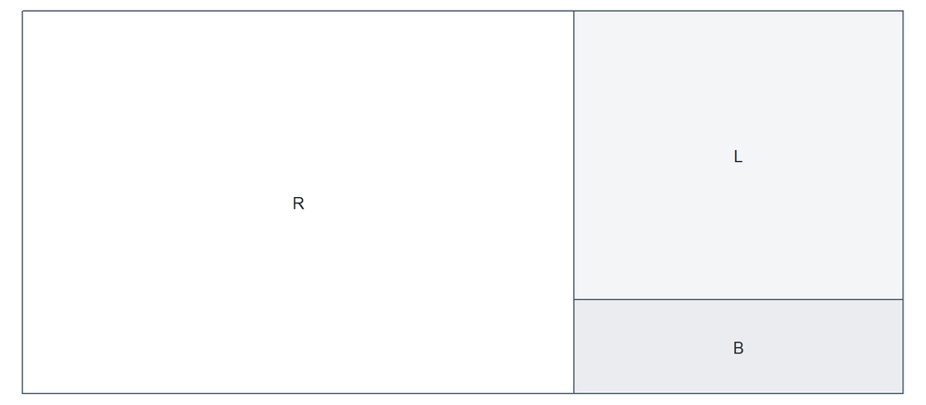

**PREVIEW**:

```
R · L · B
```

**FACTOR LEVELS**:

| Frequency | (%) | Label | Meaning |
| --- | --- | --- | --- |
| 2,895 | (62.7%) | R | R (right) |
| 1,303 | (28.2%) | L | L (left) |
| 422 | (9.1%) | B | B (both) |

categorical · unordered

throwing hand (L/R)

`throws`

Player's throwing hand, coded R (right) or L (left)

**PROPERTIES**:

| STAT | VAL | PER |
| --- | --- | --- |
| Rows | 4,620 |  |
| Distinct | 2 | (0.0%) |

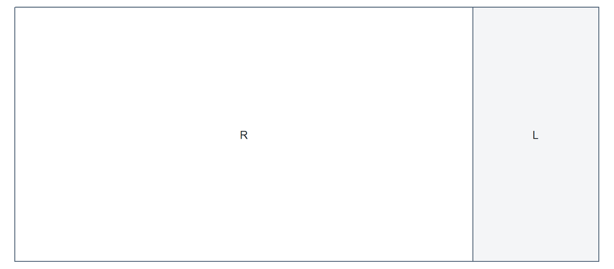

**PREVIEW**:

```
R · L
```

**FACTOR LEVELS**:

| Frequency | (%) | Label | Meaning |
| --- | --- | --- | --- |
| 3,624 | (78.4%) | R | R (right) |
| 996 | (21.6%) | L | L (left) |

## Numeric

number

weight (lbs)

`weight`

Player's weight in pounds

**PROPERTIES**:

| STAT | VAL | PER |
| --- | --- | --- |
| Rows | 4,620 |  |
| Distinct | 111 | (2.4%) |

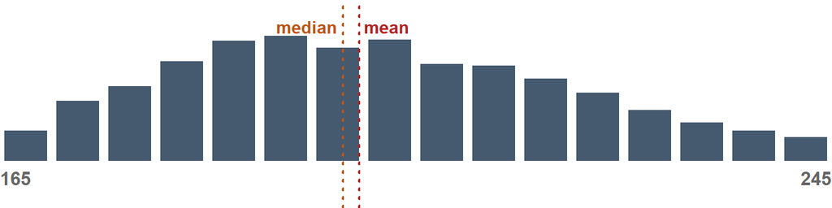

**PREVIEW**:

```
200 · 190 · 185 · 195 · 180 · 205 · 210 · 215 · 175 · 220 · 170 · 225 · 230 · 235
165 · 240 · 160 · 245 · 250 · 155 · 150 · 192 · 172 · 255 · 260 · 178 · 187 · 212
186 · 193 · 198 · 207 · 217 · 218 · 270 · 188 · 197 · 202 · 194 · 213 · 265 · 166
209 · 174 · 183 · 201 · 203 · 211 · 216 · 223 · 232 · 182 · 227 · 145 · 173 · 184
```

**STATS**:

| MIN | Q05 | Q25 | Q50 | MEAN | Q75 | Q95 | MAX |
| --- | --- | --- | --- | --- | --- | --- | --- |
| 140 | 165 | 185 | 198 | 199.58 | 215 | 240 | 315 |

**DISTRIBUTION SHAPE**:

| stat | num | interpretation |
| --- | --- | --- |
| Skew | 0.56 | MED |
| Kurtosis | 0.57 | LOW |

number · rank

height (inches)

`height`

Player's height in inches

**PROPERTIES**:

| STAT | VAL | PER |
| --- | --- | --- |
| Rows | 4,620 |  |
| Distinct | 18 | (0.4%) |

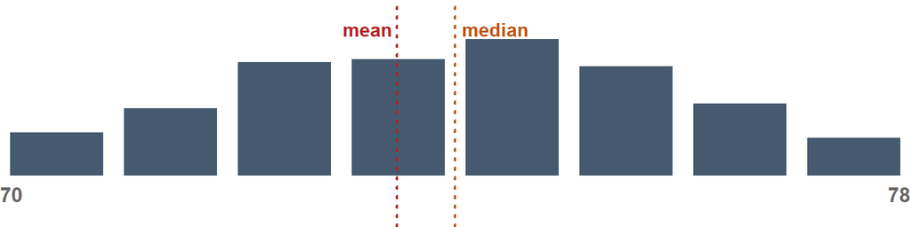

**PREVIEW**:

```
74 · 73 · 72 · 75 · 76 · 71 · 70 · 77 · 69 · 78 · 79 · 68 · 67 · 80 · 66 · 82 · 81
83
```

**STATS**:

| MIN | Q05 | Q25 | Q50 | MEAN | Q75 | Q95 | MAX |
| --- | --- | --- | --- | --- | --- | --- | --- |
| 66 | 70 | 72 | 74 | 73.49 | 75 | 77 | 83 |

**DISTRIBUTION SHAPE**:

| stat | num | interpretation |
| --- | --- | --- |
| Skew | 0.01 | LOW |
| Kurtosis | 0.18 | LOW |

number

games

`G`

Average game appearances per season

**PROPERTIES**:

| STAT | VAL | PER |
| --- | --- | --- |
| Rows | 4,620 |  |
| Distinct | 149 | (3.2%) |

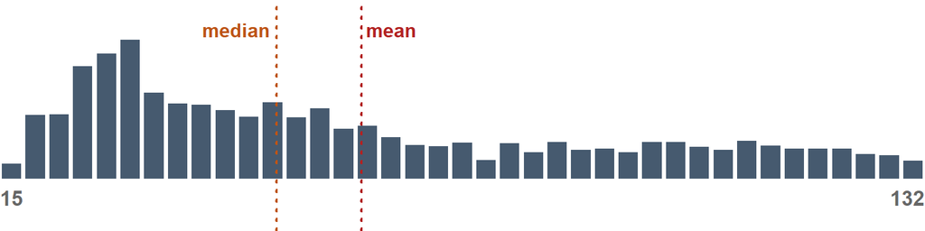

**PREVIEW**:

```
30 · 32 · 28 · 26 · 29 · 24 · 31 · 27 · 34 · 48 · 50 · 40 · 25 · 33 · 46 · 36 · 54
38 · 22 · 42 · 35 · 39 · 52 · 56 · 23 · 60 · 20 · 37 · 44 · 18 · 43 · 62 · 14 · 41
53 · 55 · 19 · 13 · 64 · 16 · 47 · 49 · 51 · 45 · 57 · 21 · 58 · 59 · 12 · 17 · 72
100 · 108 · 11 · 15 · 98 · 70 · 112 · 65 · 68 · 79 · 84 · 86 · 88 · 107 · 110
```

**STATS**:

| MIN | Q05 | Q25 | Q50 | MEAN | Q75 | Q95 | MAX |
| --- | --- | --- | --- | --- | --- | --- | --- |
| 11 | 17 | 30 | 50 | 60.73 | 89 | 130 | 159 |

**DISTRIBUTION SHAPE**:

| stat | num | interpretation |
| --- | --- | --- |
| Skew | 0.7 | MED |
| Kurtosis | -0.64 | LOW |

number

at bats

`AB`

Average at bats per season; blank if the player has no recorded at bats

**PROPERTIES**:

| STAT | VAL | PER |
| --- | --- | --- |
| Rows | 4,620 |  |
| Distinct | 581 | (12.6%) |
| Missing/NA | 633 | (13.7%) |

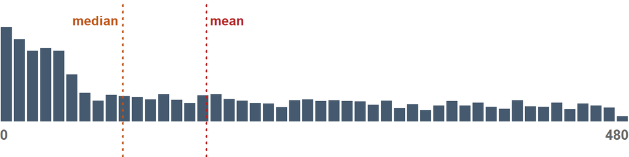

**PREVIEW**:

```
1 · 2 · 3 · 4 · 5 · 6 · 12 · 30 · 7 · 9 · 10 · 48 · 8 · 17 · 26 · 38 · 14 · 16 · 36
20 · 42 · 21 · 40 · 50 · 23 · 32 · 11 · 29 · 41 · 44 · 46 · 22 · 47 · 24 · 28 · 34
39 · 52 · 54 · 160 · 15 · 33 · 35 · 45 · 56 · 19 · 13 · 18 · 31 · 55 · 128 · 252
81 · 86 · 120 · 25 · 37 · 74 · 98 · 106 · 124 · 179 · 198 · 292 · 27 · 43 · 49
```

**STATS**:

| MIN | Q05 | Q25 | Q50 | MEAN | Q75 | Q95 | MAX |
| --- | --- | --- | --- | --- | --- | --- | --- |
| 1 | 1 | 12 | 94 | 157.74 | 276 | 474 | 634 |

**DISTRIBUTION SHAPE**:

| stat | num | interpretation |
| --- | --- | --- |
| Skew | 0.84 | MED |
| Kurtosis | -0.53 | LOW |

number

hits

`H`

Average hits per season

**PROPERTIES**:

| STAT | VAL | PER |
| --- | --- | --- |
| Rows | 4,620 |  |
| Distinct | 181 | (3.9%) |
| Zero | 1,479 | (32.0%) |

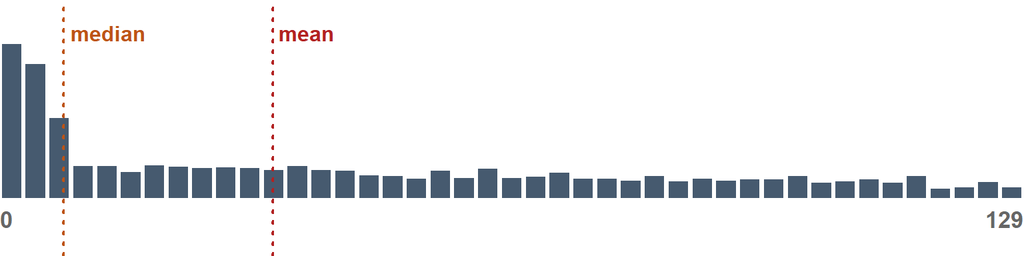

**PREVIEW**:

```
0 · 1 · 2 · 4 · 3 · 5 · 6 · 8 · 7 · 10 · 20 · 16 · 22 · 32 · 24 · 34 · 28 · 12 · 60
14 · 29 · 37 · 42 · 56 · 26 · 38 · 41 · 21 · 36 · 70 · 18 · 33 · 40 · 44 · 54 · 67
13 · 30 · 82 · 46 · 47 · 61 · 62 · 69 · 72 · 88 · 100 · 11 · 17 · 19 · 49 · 52 · 115
9 · 23 · 31 · 39 · 48 · 81 · 98 · 99 · 65 · 78 · 90 · 107 · 109 · 112 · 27
```

**STATS**:

| MIN | Q05 | Q25 | Q50 | MEAN | Q75 | Q95 | MAX |
| --- | --- | --- | --- | --- | --- | --- | --- |
| 0 | 0 | 0 | 8 | 34.42 | 61 | 128 | 197 |

**DISTRIBUTION SHAPE**:

| stat | num | interpretation |
| --- | --- | --- |
| Skew | 1.2 | HIGH |
| Kurtosis | 0.33 | LOW |

number · measurement

batting average

`AVG`

Career batting average (hits / at bats over all seasons); blank if the player has no recorded at bats

**PROPERTIES**:

| STAT | VAL | PER |
| --- | --- | --- |
| Rows | 4,620 |  |
| Distinct | 2,908 | (62.9%) |
| Missing/NA | 633 | (13.7%) |
| Zero | 548 | (11.9%) |

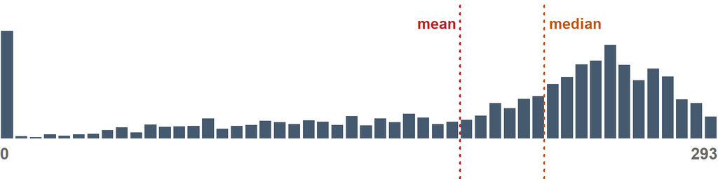

**PREVIEW**:

```
0 · 0.25 · 0.167 · 0.333 · 0.083 · 0.2 · 0.5 · 1 · 0.111 · 0.125 · 0.143 · 0.062
0.133 · 0.067 · 0.1 · 0.071 · 0.05 · 0.208 · 0.222 · 0.154 · 0.182 · 0.042 · 0.048
0.056 · 0.214
```

**STATS**:

| MIN | Q05 | Q25 | Q50 | MEAN | Q75 | Q95 | MAX |
| --- | --- | --- | --- | --- | --- | --- | --- |
| 0 | 0 | 0.11 | 0.22 | 0.19 | 0.26 | 0.29 | 1 |

**DISTRIBUTION SHAPE**:

| stat | num | interpretation |
| --- | --- | --- |
| Skew | 1.31 | HIGH |
| Kurtosis | 10.28 | HIGH |

number · measurement

slugging percentage

`SLUG`

Career slugging percentage (total bases / at bats over all seasons); blank if the player has no recorded at bats

**PROPERTIES**:

| STAT | VAL | PER |
| --- | --- | --- |
| Rows | 4,620 |  |
| Distinct | 2,962 | (64.1%) |
| Missing/NA | 633 | (13.7%) |
| Zero | 548 | (11.9%) |

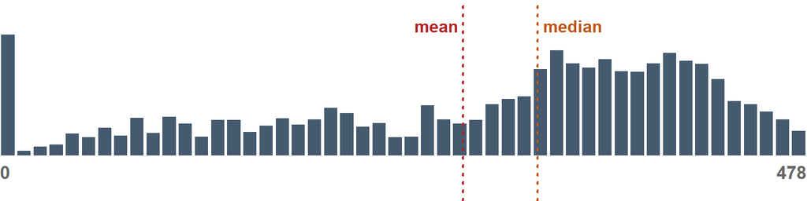

**PREVIEW**:

```
0 · 0.333 · 0.25 · 0.5 · 0.083 · 0.2 · 0.167 · 1 · 0.111 · 0.143 · 0.071 · 0.1
0.133 · 0.062 · 0.067 · 0.125 · 0.4 · 0.667 · 0.222 · 0.05 · 0.042 · 0.3 · 0.048
0.056 · 0.059 · 0.188 · 0.192
```

**STATS**:

| MIN | Q05 | Q25 | Q50 | MEAN | Q75 | Q95 | MAX |
| --- | --- | --- | --- | --- | --- | --- | --- |
| 0 | 0 | 0.14 | 0.32 | 0.27 | 0.39 | 0.48 | 4 |

**DISTRIBUTION SHAPE**:

| stat | num | interpretation |
| --- | --- | --- |
| Skew | 2.99 | HIGH |
| Kurtosis | 49.33 | HIGH |

number · usd

salary

Average annual salary over the player's career, in US dollars (written $851,950)

**PROPERTIES**:

| STAT | VAL | PER |
| --- | --- | --- |
| Rows | 4,620 |  |
| Distinct | 3,408 | (73.8%) |

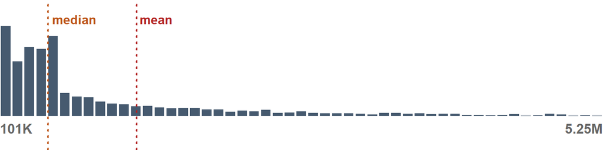

**PREVIEW**:

```
$109,000 · $200,000 · $507,500 · $100,000 · $170,000 · $300,000 · $400,000
$150,000 · $510,000 · $509,500 · $512,500 · $62,500 · $390,000 · $125,000 · $380,000
$414,000 · $120,000 · $250,000 · $508,500 · $60,000 · $140,000 · $480,000 · $520,000
$215,000 · $500,000 · $515,000 · $115,000 · $130,000 · $185,000 · $205,000
```

**STATS**:

| MIN | Q05 | Q25 | Q50 | MEAN | Q75 | Q95 | MAX |
| --- | --- | --- | --- | --- | --- | --- | --- |
| 60,000 | 109,000 | 3e+05 | 512,500 | 1,269,244 | 1,376,783 | 5,161,559 | 2.2e+07 |

**DISTRIBUTION SHAPE**:

| stat | num | interpretation |
| --- | --- | --- |
| Skew | 3.35 | HIGH |
| Kurtosis | 14.98 | HIGH |

## Text

text · person

first name

`nameFirst`

Player's first name

**PROPERTIES**:

| STAT | VAL | PER |
| --- | --- | --- |
| Rows | 4,620 |  |
| Distinct | 1,012 | (21.9%) |

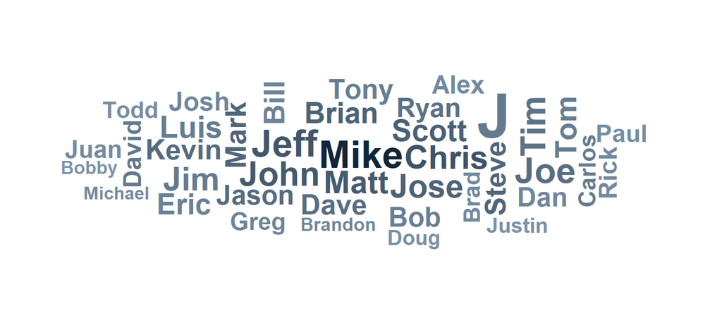

**PREVIEW**:

```
Mike · Chris · Jeff · John · Matt · Scott · Jose · Brian · Mark · Steve · Kevin
Jason · Dave · Joe · Ryan · Tim · David · Jim · Carlos · Luis · Tom · Bob · Tony
Eric · Bill · Greg · Dan · Josh · Brandon · Brad · Rick · Alex · Michael · Juan
Paul · Todd · Doug · Justin · Bobby · Rich · Ron · Tyler · Aaron · Gary · Randy
```

**MOST COMMON VALUES**:

| Value | Frequency | (%) |
| --- | --- | --- |
| Mike | 160 | (3.5%) |
| Chris | 85 | (1.8%) |
| Jeff | 81 | (1.8%) |
| John | 75 | (1.6%) |
| Matt | 74 | (1.6%) |
| Scott | 68 | (1.5%) |

text

state of birth

`birthState`

State or province where the player was born: a two-letter postal code for US states, a region name elsewhere (e.g. La Romana); blank if unknown

**PROPERTIES**:

| STAT | VAL | PER |
| --- | --- | --- |
| Rows | 4,620 |  |
| Distinct | 210 | (4.5%) |
| Missing/NA | 167 | (3.6%) |

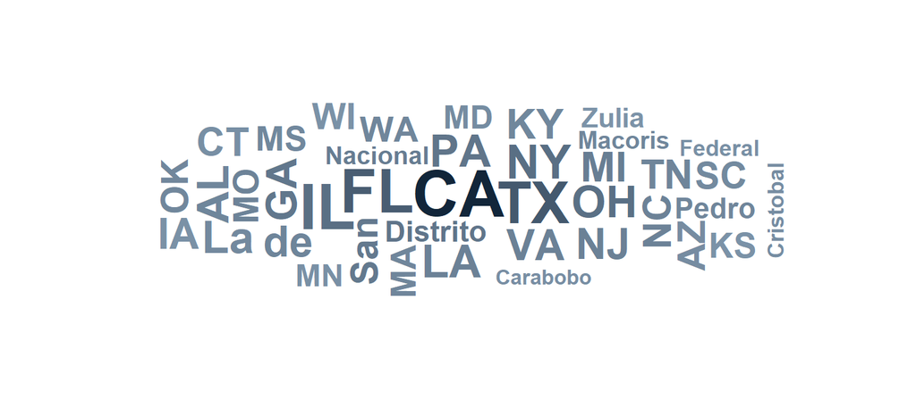

**PREVIEW**:

```
CA · TX · FL · NY · IL · OH · PA · GA · Distrito Nacional · MI · VA · LA · NJ · NC
IN · MO · TN · AL · WA · MA · San Pedro de Macoris · KY · OK · MS · SC · OR · MD
AZ · San Cristobal · Carabobo · CT · MN · Distrito Federal · IA · KS · WI · Zulia
CO · HI · ON · Peravia · Santiago · NV · BC · La Habana · Anzoategui · AR · Aragua
```

**MOST COMMON VALUES**:

| Value | Frequency | (%) |
| --- | --- | --- |
| CA | 826 | (17.9%) |
| TX | 293 | (6.3%) |
| FL | 260 | (5.6%) |
| NY | 155 | (3.4%) |
| IL | 154 | (3.3%) |
| OH | 150 | (3.2%) |

## Temporal

temporal · calendar

date of birth

`birthDate`

Player's birth date, written Mon DD, YYYY (e.g. Dec 27, 1981)

**PROPERTIES**:

| STAT | VAL | PER |
| --- | --- | --- |
| Rows | 4,620 |  |
| Distinct | 3,965 | (85.8%) |

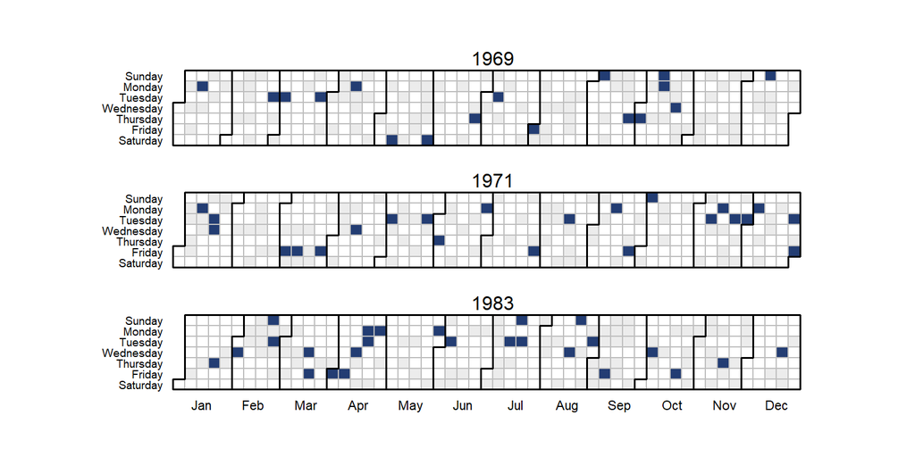

**PREVIEW**:

```
Mar 25, 1969 · Mar 05, 1971 · May 11, 1964 · Dec 07, 1963 · Jul 15, 1980
Nov 23, 1971 · Oct 21, 1979 · Apr 05, 1976 · Apr 08, 1983 · Apr 10, 1963
Apr 11, 1972 · Apr 14, 1966 · Apr 18, 1959 · Apr 18, 1990 · Apr 19, 1977
Apr 19, 1983 · Apr 26, 1972 · Apr 27, 1975 · Aug 02, 1979 · Aug 06, 1955
```

temporal · year

year of birth

`birthYear`

Year in which the player was born (YYYY)

**PROPERTIES**:

| STAT | VAL | PER |
| --- | --- | --- |
| Rows | 4,620 |  |
| Distinct | 56 | (1.2%) |

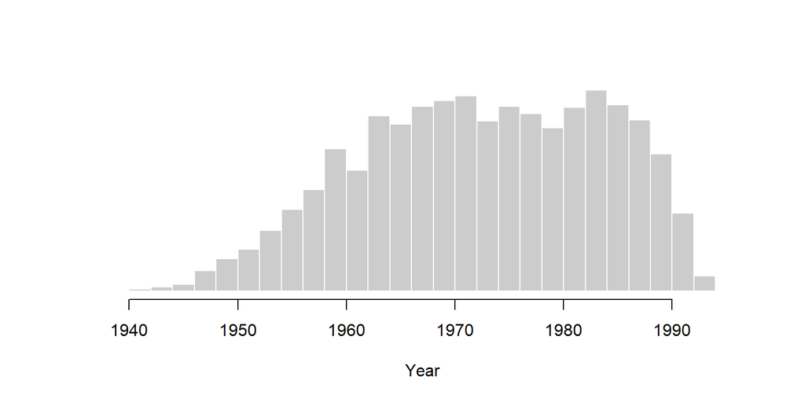

**PREVIEW**:

```
1983 · 1971 · 1969 · 1972 · 1975 · 1986 · 1987 · 1964 · 1984 · 1970 · 1982 · 1967
1968 · 1977 · 1981 · 1985 · 1976 · 1960 · 1973 · 1978 · 1965 · 1966 · 1974 · 1980
1963 · 1979 · 1988 · 1989 · 1962 · 1990 · 1961 · 1959 · 1958 · 1991 · 1957 · 1956
1954 · 1955 · 1992 · 1953 · 1952 · 1951 · 1949 · 1950 · 1948 · 1993 · 1947 · 1945
```

temporal · month_of_year

month of birth (Mon)

`birthMonth`

Month in which the player was born, as a three-letter abbreviation (Jan-Dec)

**PROPERTIES**:

| STAT | VAL | PER |
| --- | --- | --- |
| Rows | 4,620 |  |
| Distinct | 12 | (0.3%) |

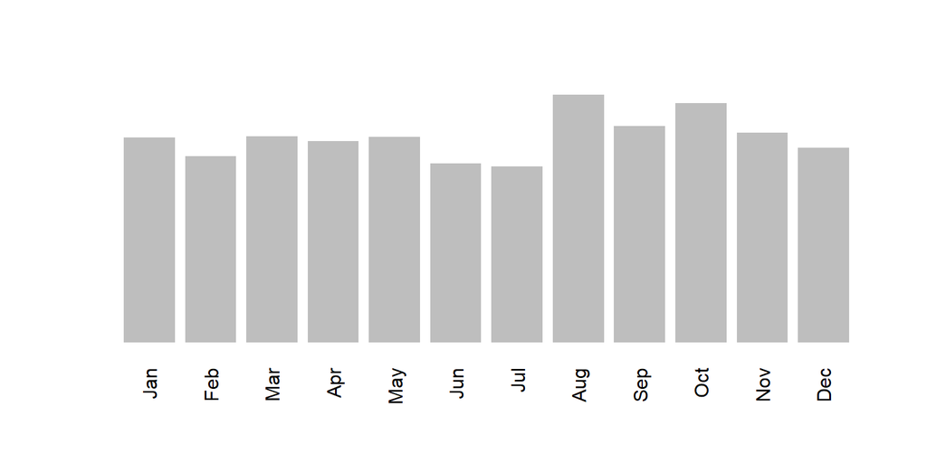

**PREVIEW**:

```
Aug · Oct · Sep · Nov · Mar · May · Jan · Apr · Dec · Feb · Jun · Jul
```

temporal · calendar

date of first appearance

`debut`

Date of the player's first major league appearance (YYYY-MM-DD)

**PROPERTIES**:

| STAT | VAL | PER |
| --- | --- | --- |
| Rows | 4,620 |  |
| Distinct | 2,948 | (63.8%) |

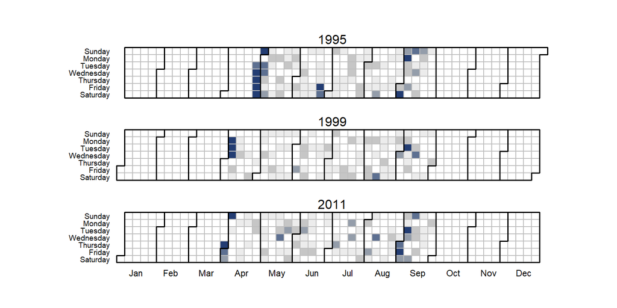

**PREVIEW**:

```
1995-04-26 · 2003-04-02 · 1998-03-31 · 2003-03-31 · 2006-04-03 · 2007-04-02
1996-04-03 · 2005-04-04 · 2011-09-06 · 1992-09-01 · 1995-04-27 · 1995-04-29
1998-04-02 · 1999-04-05 · 1999-04-06 · 1994-04-04 · 1995-04-28 · 1995-04-30
1999-04-07 · 2007-09-01 · 2008-03-31 · 2008-04-01 · 2008-09-02 · 2010-04-05
```

temporal · calendar

date of last appearance

`finalGame`

Date of the player's last major league appearance (YYYY-MM-DD)

**PROPERTIES**:

| STAT | VAL | PER |
| --- | --- | --- |
| Rows | 4,620 |  |
| Distinct | 2,320 | (50.2%) |

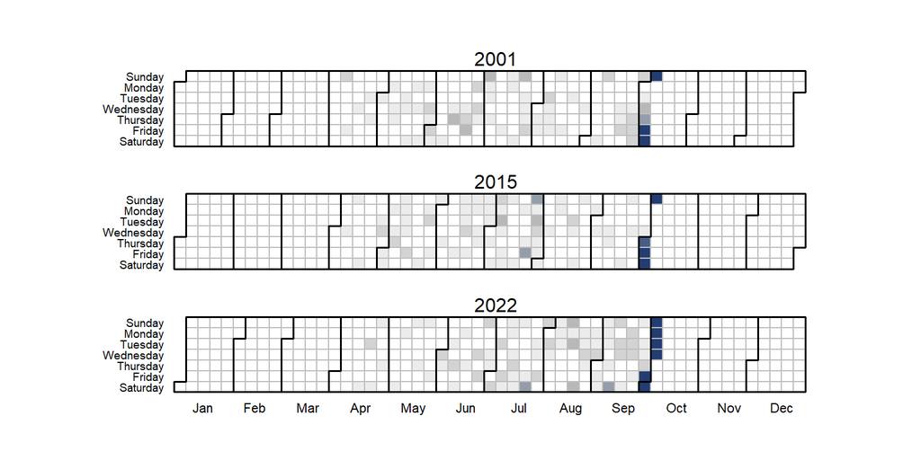

**PREVIEW**:

```
2022-10-05 · 2022-10-04 · 1999-10-03 · 2001-10-07 · 2009-10-04 · 2000-10-01
2007-09-30 · 1996-09-29 · 2010-10-03 · 2017-10-01 · 2012-10-03 · 2016-10-02
1998-09-27 · 2003-09-28 · 2013-09-29 · 2015-10-04 · 2014-09-28 · 2018-09-30
2005-10-02 · 1987-10-04 · 1992-10-04 · 1993-10-03 · 2008-09-28 · 1995-10-01
```